# Chen_Ruoyan_A1

## A1: Linear Modeling Case Study

#### DAT-5390 | Computational Data Analytics with Python

Ruoyan Chen - Faculty of Analytics  
Hult International Business School

### Introduction

The objective of this case study is to develop a predictive model for daily bike rentals in Chicago city. The dataset comprises various features, including weather conditions, temporal data, and operational days, which potentially influence bike rental patterns. The analysis is divided into the following sections:

- Exploratory Data Analysis and Data Preprocessing.
- Feature Engineering.
- Candidate Model Development and Final Model Selection.

The aim is to uncover insights and build a model that accurately forecasts bike rental demand.

## Part I: Imports and Data Check

```python
## importing libraries ##

# for this template
import pandas as pd
import matplotlib.pyplot as plt
import seaborn as sns
import numpy as np
import statsmodels.formula.api as smf
import warnings
warnings.filterwarnings('ignore')

from sklearn.model_selection import train_test_split
from sklearn.linear_model import LinearRegression, Lasso, Ridge, SGDRegressor
from sklearn.neighbors import KNeighborsRegressor
from sklearn.tree import DecisionTreeRegressor
from sklearn.metrics import mean_squared_error, mean_absolute_error, r2_score
from sklearn.model_selection import RandomizedSearchCV
from sklearn.preprocessing import StandardScaler


# setting pandas print options (optional)
pd.set_option('display.max_rows', 500)
pd.set_option('display.max_columns', 500)
pd.set_option('display.width', 1000)
```

```python
## importing data ##

# reading modeling data into Python
modeling_data = './datasets/chicago_training_data.xlsx'

# calling this df_train
df_train = pd.read_excel(io         = modeling_data,
                         sheet_name = 'train',
                         header     = 0,
                         index_col  = 'ID')



# reading testing data into Python
testing_data = './datasets/test.xlsx'

# calling this df_test
df_test = pd.read_excel(io         = testing_data,
                        sheet_name = 'data',
                        header     = 0,
                        index_col  = 'ID')
```

```python
# concatenating datasets together for mv analysis and feature engineering
df_train['set'] = 'Not Kaggle'
df_test ['set'] = 'Kaggle'

# concatenating both datasets together for mv and feature engineering
df_full = pd.concat(objs = [df_train, df_test],
                    axis = 0,
                    ignore_index = False)


# checking data
df_full.head(n = 5)
```

| ID | DateHour | Temperature(F) | Humidity(%) | Wind speed (mph) | Visibility(miles) | DewPointTemperature(F) | Rainfall(in) | Snowfall(in) | SolarRadiation(MJ/m2) | Holiday | FunctioningDay | RENTALS | set |
| --- | --- | --- | --- | --- | --- | --- | --- | --- | --- | --- | --- | --- | --- |
| mb_1039 | 2023-10-14 05:59:54.810000 | 52 | 81 | 0.4 | 2.9 | 46.4 | 0.0 | 0.0 | 0.00 | No | Yes | 519.0 | Not Kaggle |
| mb_1330 | 2023-10-26 08:59:53.355000 | 51 | 53 | 2.2 | NaN | 35.2 | 0.0 | 0.0 | 1.01 | No | Yes | 1251.0 | Not Kaggle |
| mb_551 | 2023-09-23 21:59:57.250000 | 56 | 49 | 2.5 | 3.4 | 38.8 | 0.0 | 0.0 | 0.00 | No | Yes | 1685.0 | Not Kaggle |
| mb_2103 | 2023-12-19 14:00:00 | 69 | 32 | 9.8 | 12.4 | 38.7 | 0.0 | 0.0 | 2.36 | No | No | 0.0 | Not Kaggle |
| mb_1430 | 2023-10-30 12:59:52.855000 | 53 | 20 | 2.9 | 10.8 | 12.9 | 0.0 | 0.0 | 1.96 | No | Yes | 814.0 | Not Kaggle |

```python
# checking available features
df_full.columns
```

```
Index(['DateHour', 'Temperature(F)', 'Humidity(%)', 'Wind speed (mph)', 'Visibility(miles)', 'DewPointTemperature(F)', 'Rainfall(in)', 'Snowfall(in)', 'SolarRadiation(MJ/m2)', 'Holiday', 'FunctioningDay', 'RENTALS', 'set'], dtype='object')
```

```python
# Converting 'DateHour' to string
df_full['DateHour'] = df_full['DateHour'].astype(str)

print(df_full.describe())
```

```
       Temperature(F)  Humidity(%)  Wind speed (mph)  Visibility(miles)  DewPointTemperature(F)  Rainfall(in)  Snowfall(in)  SolarRadiation(MJ/m2)      RENTALS
count     2184.000000  2184.000000       2184.000000        2108.000000             2117.000000   2184.000000   2184.000000            2078.000000  1638.000000
mean        57.389652    59.228480          3.344780           9.646964               42.036089      0.004858      0.002015               0.547161   828.153846
std         12.861669    18.686445          2.071144           3.492413               13.997667      0.037354      0.018550               0.810564   657.599846
min         26.000000    13.000000          0.000000           0.000000               -2.200000      0.000000      0.000000               0.000000     0.000000
25%         48.000000    44.000000          1.800000           7.400000               33.400000      0.000000      0.000000               0.000000   241.500000
50%         57.000000    59.000000          2.900000          11.700000               41.900000      0.000000      0.000000               0.000000   761.500000
75%         68.000000    74.000000          4.500000          12.400000               51.600000      0.000000      0.000000               0.980000  1203.750000
max         91.000000    97.000000         12.800000          12.400000               75.000000      0.710000      0.300000               3.180000  3303.000000
```

```python
#!##############################!#
#!#   set response variable    #!#
#!##############################!#

y_variable = 'RENTALS'
```

## Part II: Data Preparation

Starting with plotting histograms, which helps to understand the shape and spread.

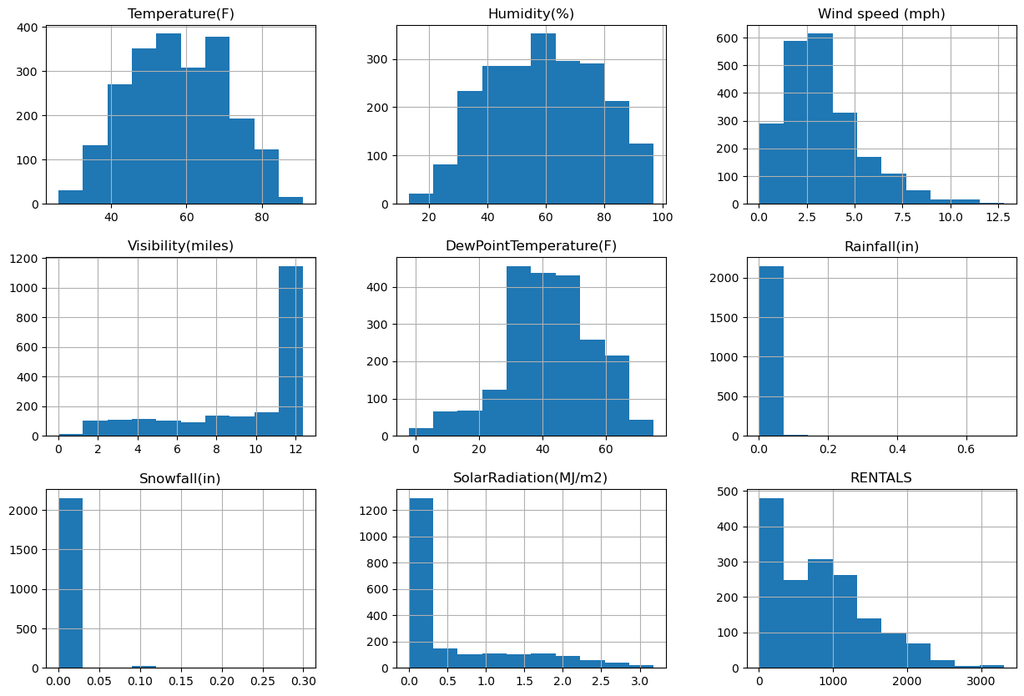

```python
# Develop a histogram to analyze the distribution of the variables
df_full.hist(figsize=(15, 10))
plt.show()
```

As show in the graph, the distribution of Temperature and Humidity are normal. The distribution of Wind Speed, Visibility, Dew Point Temperature, Rainfall, Snowfall, Solar Radiation and REANTALS are skewed.

```python
# Developing a correlation matrix
correlation_matrix = df_full.corr(numeric_only=True)
print(correlation_matrix['RENTALS'].sort_values(ascending=False))
```

```
RENTALS                   1.000000
Temperature(F)            0.322811
SolarRadiation(MJ/m2)     0.207526
Wind speed (mph)          0.186261
DewPointTemperature(F)    0.030903
Visibility(miles)         0.004390
Snowfall(in)             -0.086884
Rainfall(in)             -0.145802
Humidity(%)              -0.395309
Name: RENTALS, dtype: float64
```

Then the correlation between figures and RENTALS are measured.

As shown in the output, there are positive relationships between Temperature and RENTALS, as well as SolarRadiation, Wind speed, DewPointTemperature and Visibility, they all have positive relationship with RENTALS. This means that a increase in Temperature, SolarRadiation, Wind speed, DewPointTemperature and Visibility will relate to a increase in RENTALS.

There are negative relationships between Snowfall, Rainfall, Humidity and RENTALS, which indicates that as Snowfall, Rainfall, Humidity increases, RENTALS decreases.

### Missing Value Analysis and Imputation

```python
## Missing Value Imputation ##

# imputation of missing values using the mean
print(df_full.isnull().sum())
df_full = df_full.fillna(df_full.median(numeric_only=True))
```

```
DateHour                    0
Temperature(F)              0
Humidity(%)                 0
Wind speed (mph)            0
Visibility(miles)          76
DewPointTemperature(F)     67
Rainfall(in)                0
Snowfall(in)                0
SolarRadiation(MJ/m2)     106
Holiday                     0
FunctioningDay              0
RENTALS                   546
set                         0
dtype: int64
```

Missing values addressed in the ‘Visibility’, ‘DewPointTemperature’, ‘SolarRadiation’ and 'RENTALS' columns. Median imputation can be used when the distribution of the data is skewed as it is more resistant to outliers than the mean.

### Transformations

```python
## Transformations ##

# log transformation of skewed variables
df_full['log_wind'] = np.log1p(df_full['Wind speed (mph)'])
df_full['log_DewPointTemperature'] = np.log1p(df_full['DewPointTemperature(F)'])
df_full['log_visibility'] = np.log1p(df_full['Visibility(miles)'])
df_full['log_rainfall'] = np.log1p(df_full['Rainfall(in)'])
df_full['log_snowfall'] = np.log1p(df_full['Snowfall(in)'])
df_full['log_solar'] = np.log1p(df_full['SolarRadiation(MJ/m2)'])
```

log transformation was applied to mitigate the effects of skewness, enhancing model performance

```python
df_full.tail()
```

| ID | DateHour | Temperature(F) | Humidity(%) | Wind speed (mph) | Visibility(miles) | DewPointTemperature(F) | Rainfall(in) | Snowfall(in) | SolarRadiation(MJ/m2) | Holiday | FunctioningDay | RENTALS | set | log_wind | log_DewPointTemperature | log_visibility | log_rainfall | log_snowfall | log_solar |
| --- | --- | --- | --- | --- | --- | --- | --- | --- | --- | --- | --- | --- | --- | --- | --- | --- | --- | --- | --- |
| mb_729 | 2023-10-01 07:59:56.360000 | 67 | 53 | 3.1 | 2.3 | 46.4 | 0.0 | 0.0 | 0.50 | No | Yes | 761.5 | Kaggle | 1.410987 | 3.858622 | 1.193922 | 0.0 | 0.0 | 0.405465 |
| mb_767 | 2023-10-02 21:59:56.170000 | 50 | 55 | 3.6 | 12.4 | 32.4 | 0.0 | 0.0 | 0.00 | No | Yes | 761.5 | Kaggle | 1.526056 | 3.508556 | 2.595255 | 0.0 | 0.0 | 0.000000 |
| mb_267 | 2023-09-12 01:59:58.670000 | 45 | 62 | 0.4 | 12.4 | 34.3 | 0.0 | 0.0 | 0.00 | No | Yes | 761.5 | Kaggle | 0.336472 | 3.563883 | 2.595255 | 0.0 | 0.0 | 0.000000 |
| mb_1696 | 2023-12-02 15:00:00 | 66 | 40 | 6.7 | 12.4 | 39.4 | 0.0 | 0.0 | 1.66 | No | Yes | 761.5 | Kaggle | 2.041220 | 3.698830 | 2.595255 | 0.0 | 0.0 | 0.978326 |
| mb_1225 | 2023-10-21 23:59:53.880000 | 68 | 73 | 2.7 | 12.4 | 58.1 | 0.0 | 0.0 | 0.00 | No | No | 761.5 | Kaggle | 1.308333 | 4.079231 | 2.595255 | 0.0 | 0.0 | 0.000000 |

### Feature Engineering

```python
## Feature Engineering ##

# get hours and rush hours in time feature
time_list = df_full['DateHour'].tolist()
for i in range(len(time_list)):
    time_list[i] = time_list[i][11:13]
df_full['hour'] = time_list
df_full['hour'] = df_full['hour'].astype(float)

# get months
time_list = df_full['DateHour'].tolist()
for i in range(len(time_list)):
    time_list[i] = time_list[i][5:7]
df_full['month'] = time_list
df_full['month'] = df_full['month'].astype(float)

# Use temperature and wind speed to calculate the wind chill for different days as these can affect rental comfort
df_full['Wind_Chill']=(35.74 + 0.6215 * df_full['Temperature(F)'] - 35.75 * (df_full['Wind speed (mph)']** 0.16) + 0.4275* df_full['Temperature(F)'] * (df_full['Wind speed (mph)']** 0.16))

# get dummies
df_full = pd.get_dummies(df_full, columns=['Holiday', 'FunctioningDay'], drop_first=True, dtype=int)

df_full.head(n=10)
```

| ID | DateHour | Temperature(F) | Humidity(%) | Wind speed (mph) | Visibility(miles) | DewPointTemperature(F) | Rainfall(in) | Snowfall(in) | SolarRadiation(MJ/m2) | RENTALS | set | log_wind | log_DewPointTemperature | log_visibility | log_rainfall | log_snowfall | log_solar | hour | month | Wind_Chill | Holiday_Yes | FunctioningDay_Yes |
| --- | --- | --- | --- | --- | --- | --- | --- | --- | --- | --- | --- | --- | --- | --- | --- | --- | --- | --- | --- | --- | --- | --- |
| mb_1039 | 2023-10-14 05:59:54.810000 | 52 | 81 | 0.4 | 2.9 | 46.4 | 0.0 | 0.0 | 0.00 | 519.0 | Not Kaggle | 0.336472 | 3.858622 | 1.360977 | 0.0 | 0.0 | 0.000000 | 5.0 | 10.0 | 56.381672 | 0 | 1 |
| mb_1330 | 2023-10-26 08:59:53.355000 | 51 | 53 | 2.2 | 11.7 | 35.2 | 0.0 | 0.0 | 1.01 | 1251.0 | Not Kaggle | 1.163151 | 3.589059 | 2.541602 | 0.0 | 0.0 | 0.698135 | 8.0 | 10.0 | 51.613676 | 0 | 1 |
| mb_551 | 2023-09-23 21:59:57.250000 | 56 | 49 | 2.5 | 3.4 | 38.8 | 0.0 | 0.0 | 0.00 | 1685.0 | Not Kaggle | 1.252763 | 3.683867 | 1.481605 | 0.0 | 0.0 | 0.000000 | 21.0 | 9.0 | 56.869222 | 0 | 1 |
| mb_2103 | 2023-12-19 14:00:00 | 69 | 32 | 9.8 | 12.4 | 38.7 | 0.0 | 0.0 | 2.36 | 0.0 | Not Kaggle | 2.379546 | 3.681351 | 2.595255 | 0.0 | 0.0 | 1.211941 | 14.0 | 12.0 | 69.615054 | 0 | 0 |
| mb_1430 | 2023-10-30 12:59:52.855000 | 53 | 20 | 2.9 | 10.8 | 12.9 | 0.0 | 0.0 | 1.96 | 814.0 | Not Kaggle | 1.360977 | 2.631889 | 2.468100 | 0.0 | 0.0 | 1.085189 | 12.0 | 10.0 | 53.155406 | 0 | 1 |
| mb_781 | 2023-10-03 11:59:56.100000 | 50 | 72 | 4.5 | 11.7 | 42.3 | 0.0 | 0.0 | 0.30 | 731.0 | Not Kaggle | 1.704748 | 3.768153 | 2.541602 | 0.0 | 0.0 | 0.262364 | 11.0 | 10.0 | 48.528868 | 0 | 1 |
| mb_1642 | 2023-11-30 09:00:00 | 28 | 33 | 2.0 | 9.6 | 3.7 | 0.0 | 0.0 | 0.56 | 800.0 | Not Kaggle | 1.098612 | 1.547563 | 2.360854 | 0.0 | 0.0 | 0.444686 | 9.0 | 11.0 | 26.572912 | 0 | 1 |
| mb_870 | 2023-10-07 04:59:55.655000 | 72 | 70 | 2.7 | 8.1 | 58.6 | 0.0 | 0.0 | 0.00 | 260.0 | Not Kaggle | 1.308333 | 4.087656 | 2.208274 | 0.0 | 0.0 | 0.000000 | 4.0 | 10.0 | 74.661945 | 0 | 1 |
| mb_1483 | 2023-11-23 18:00:00 | 61 | 41 | 3.1 | 12.4 | 37.2 | 0.0 | 0.0 | 0.06 | 1699.0 | Not Kaggle | 1.410987 | 3.642836 | 2.595255 | 0.0 | 0.0 | 0.058269 | 18.0 | 11.0 | 62.059547 | 0 | 1 |
| mb_092 | 2023-09-04 18:59:59.545000 | 84 | 54 | 3.4 | 12.4 | 62.8 | 0.0 | 0.0 | 0.05 | 2085.0 | Not Kaggle | 1.481605 | 4.155753 | 2.595255 | 0.0 | 0.0 | 0.048790 | 18.0 | 9.0 | 88.140606 | 0 | 1 |

- 'hour': Bike rentals may vary throughout the day. Extracting hour from the 'DateHour' column allows us to capture daily rental patterns which identifying peak rental times.
- 'month': Seasonality affects weather and consequently bike rental patterns. Extracting the month from the 'DateHour' column can help capture this.
- 'Wind_Chill': Wind Chill is a term used to describe what the air temperature feels like to the human skin due to the combination of cold temperatures and winds blowing on exposed skin. As these can affect rental comfort, calculating the wind chill using temperature and wind speed.
- 'Holiday_Yes' & 'FunctioningDay_Yes': The get_dummies() function is used to convert 'Holiday' and 'FunctioningDay' from categorical variables into indicator variables, to make them have a value of 0 or 1. And it produces new columns name 'Holiday_Yes' and 'FunctioningDay_Yes'.

## Part III: Data Partitioning

### Separating the Kaggle Data

```python
## parsing out testing data (needed for later) ##

# dataset for kaggle
kaggle_data = df_full[ df_full['set'] == 'Kaggle' ].copy()


# dataset for model building
df = df_full[ df_full['set'] == 'Not Kaggle' ].copy()


# dropping set identifier (kaggle)
kaggle_data.drop(labels = 'set',
                 axis = 1,
                 inplace = True)


# dropping set identifier (model building)
df.drop(labels = 'set',
        axis = 1,
        inplace = True)
```

### Train-Test Split

```python
#!###########################!#
#!# choose your x-variables #!#
#!###########################!#

x_features = ['Wind_Chill', 'log_wind', 'log_visibility',
              'DewPointTemperature(F)', 'log_DewPointTemperature',
              'log_rainfall', 'log_snowfall', 'log_solar', 'Holiday_Yes',
              'FunctioningDay_Yes', 'Temperature(F)', 'Humidity(%)',
              'Wind speed (mph)', 'Visibility(miles)', 'hour', 'month']
```

```python
# prepping data for train-test split
y_data = df[y_variable]


# removing non-numeric columns and missing values
x_data = df[x_features].copy().select_dtypes(include=[int, float]).dropna(axis = 1)


# storing remaining x_features after the step above
x_features = list(x_data.columns)


# train-test split (to validate the model)
x_train, x_test, y_train, y_test = train_test_split(x_data,
                                                    y_data,
                                                    test_size    = 0.25,
                                                    random_state = 702 )


# results of train-test split
print(f"""
Original Dataset Dimensions
---------------------------
Observations (Rows): {df.shape[0]}
Features  (Columns): {df.shape[1]}


Training Data (X-side)
----------------------
Observations (Rows): {x_train.shape[0]}
Features  (Columns): {x_train.shape[1]}


Training Data (y-side)
----------------------
Feature Name:        {y_train.name}
Observations (Rows): {y_train.shape[0]}


Testing Data (X-side)
---------------------
Observations (Rows): {x_test.shape[0]}
Features  (Columns): {x_test.shape[1]}


Testing Data (y-side)
---------------------
Feature Name:        {y_test.name}
Observations (Rows): {y_test.shape[0]}""")
```

```
Original Dataset Dimensions
---------------------------
Observations (Rows): 1638
Features  (Columns): 21


Training Data (X-side)
----------------------
Observations (Rows): 1228
Features  (Columns): 15


Training Data (y-side)
----------------------
Feature Name:        RENTALS
Observations (Rows): 1228


Testing Data (X-side)
---------------------
Observations (Rows): 410
Features  (Columns): 15


Testing Data (y-side)
---------------------
Feature Name:        RENTALS
Observations (Rows): 410
```

## Part III: Candidate Modeling

```python
## Candidate Modeling ##

# naming the model
models = {
    'OLS Linear Regression': LinearRegression(),
    'Lasso Regression': Lasso(),
    'Ridge Regression': Ridge(),
    'Elastic Net Regression' : SGDRegressor(),
    'K-Nearest Neighbors': KNeighborsRegressor(),
    'Decision Tree Regressor': DecisionTreeRegressor()
}
```

```python
for model_name, model in models.items():
    # FITTING to the training data
    model.fit(x_train, y_train)
    # PREDICTING on new data
    model_pred = model.predict(x_test)

    # SCORING the results
    model_train_score = model.score(x_train, y_train).round(4)
    model_test_score  = model.score(x_test, y_test).round(4)
    model_gap         = abs(model_train_score - model_test_score).round(4)

    # dynamically printing results
    model_summary =  f"""\
    Model Name:     {model_name}
    Train_Score:    {model_train_score}
    Test_Score:     {model_test_score}
    Train-Test Gap: {model_gap}
    """

    print(model_summary)
```

```
    Model Name:     OLS Linear Regression
    Train_Score:    0.5593
    Test_Score:     0.5344
    Train-Test Gap: 0.0249

    Model Name:     Lasso Regression
    Train_Score:    0.5563
    Test_Score:     0.5225
    Train-Test Gap: 0.0338

    Model Name:     Ridge Regression
    Train_Score:    0.5581
    Test_Score:     0.5273
    Train-Test Gap: 0.0308

    Model Name:     Elastic Net Regression
    Train_Score:    -1.7589668364383564e+19
    Test_Score:     -1.6695673438951084e+19
    Train-Test Gap: 8.939949254324797e+17

    Model Name:     K-Nearest Neighbors
    Train_Score:    0.6039
    Test_Score:     0.3316
    Train-Test Gap: 0.2723

    Model Name:     Decision Tree Regressor
    Train_Score:    1.0
    Test_Score:     0.6514
    Train-Test Gap: 0.3486
```

#### Train Score:

The train score indicates the coefficient of determination (R-squared) for the training data.

#### Test Score:

The test score represents the R-squared value for the test data. It indicates how well your model generalizes to unseen data.

#### Train-Test Gap:

The train-test gap refers to the absolute difference between the train score and the test score.

#### OLS Linear Regression, Lasso Regression and Ridge Regression

There is not a huge difference between the scores of OLS Linear Regression, Lasso Regression and Ridge Regression in this case. They provide similar Train_Scores around 0.56 and Test_Scores around 0.53. A small Train_Test gap suggests that the models is not overfitting excessively, as it performs relatively similarly on both the training and test datasets.

#### Elastic Net Regression

The scores for the Elastic Net Regression seem unusually large and negative.

#### K-Nearest Neighbors

The K-Nearest Neighbors model seems to have a good performance on the training data, with an Train_Score of 0.6039. However, its performance drops on the test data, with a Test_Score of 0.3316. The relatively large train-test gap of 0.2723 suggests that the model might be overfitting to the training data.

#### Decision Tree Regressor

We got a high score 1.0 on our training data and less score on test data. The model overfitted.

### Model Results

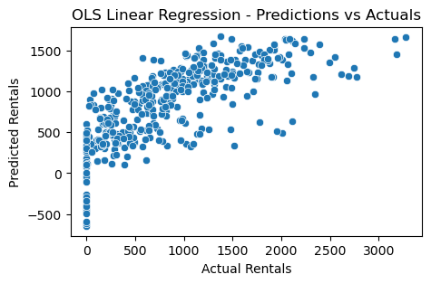

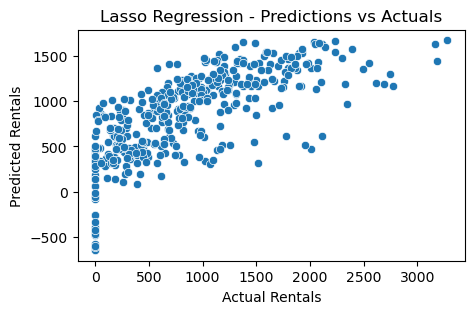

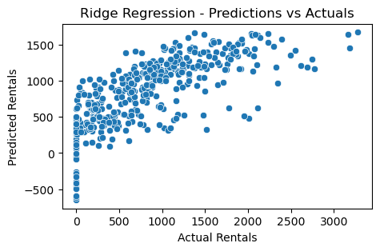

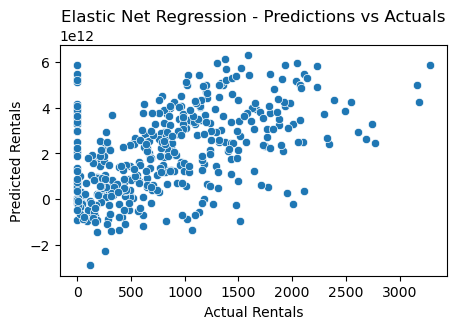

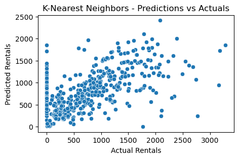

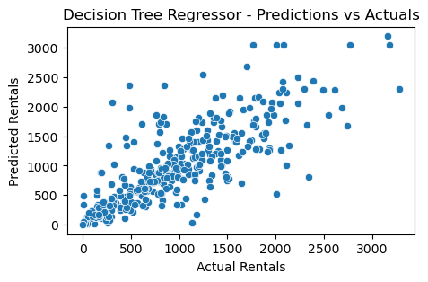

```python
## Model Results ##

for model_name, model in models.items():
    # Predictions
    y_pred = model.predict(x_test)

    # Visualize predictions vs actual values
    plt.figure(figsize=(5, 3))
    sns.scatterplot(x=y_test, y=y_pred)
    plt.title(f'{model_name} - Predictions vs Actuals')
    plt.xlabel('Actual Rentals')
    plt.ylabel('Predicted Rentals')
    plt.show()
```

Scatter plots visually indicates how well each model's predictions align with the actual values.

```python
for model_name, model in models.items():
    # Predictions
    y_pred = model.predict(x_test)

    # Print metrics
    mse = mean_squared_error(y_test, y_pred)
    mae = mean_absolute_error(y_test, y_pred)
    r2 = r2_score(y_test, y_pred)

    print(f'{model_name} Metrics:')
    print(f'Mean Squared Error: {mse}')
    print(f'Mean Absolute Error: {mae}')
    print(f'R-squared: {r2}')
    print('\n')
```

```
OLS Linear Regression Metrics:
Mean Squared Error: 213541.5105783342
Mean Absolute Error: 351.52951981301806
R-squared: 0.534441259881475


Lasso Regression Metrics:
Mean Squared Error: 219000.76871562572
Mean Absolute Error: 356.5322014832045
R-squared: 0.5225390993437142


Ridge Regression Metrics:
Mean Squared Error: 216822.82887096147
Mean Absolute Error: 354.69564039849354
R-squared: 0.5272873982921937


Elastic Net Regression Metrics:
Mean Squared Error: 7.657936623353971e+24
Mean Absolute Error: 2252144094105.6646
R-squared: -1.6695673438951086e+19


K-Nearest Neighbors Metrics:
Mean Squared Error: 306600.20868292684
Mean Absolute Error: 378.66292682926826
R-squared: 0.3315566304278891


Decision Tree Regressor Metrics:
Mean Squared Error: 159902.4975609756
Mean Absolute Error: 248.18048780487806
R-squared: 0.6513839154519572
```

### Hyperparameter Tuning

#### OLS Linear Regression

OLS linear regression does not have any hyperparameters

#### Lasso Regression

For Lasso Regressor, we take the alpha(λ-parameter) value as a bunch of possible random values. By doing RandomizedSearch to find the best parameters which will work for the Lasso Regressor.

```python
tuned_lasso = Lasso()

tuned_lasso_cv = RandomizedSearchCV(estimator  = tuned_lasso,
                           param_distributions = {'alpha':[0.01, 0.1, 1.0, 10.0]},
                           cv                  = 5,
                           n_iter              = 1000,
                           random_state        = 101)

# Fit the model using RandomizedSearchCV
tuned_lasso_cv.fit(x_data, y_data)

# Use the best model found
print("Tuned Parameters        :", tuned_lasso_cv.best_params_)
print("Tuned Training R-Squared:", tuned_lasso_cv.best_score_.round(4))
```

```
Tuned Parameters        : {'alpha': 1.0}
Tuned Training R-Squared: 0.542
```

#### Ridge Regression

For Ridege Regression, by doing RandomizedSearch to find the best alpha(λ) parameter value.

```python
tuned_ridge = Ridge()

tuned_ridge_cv = RandomizedSearchCV(estimator  = tuned_ridge,
                           param_distributions = {'alpha':[0.01, 0.1, 1.0, 10.0]},
                           cv                  = 5,
                           n_iter              = 1000,
                           random_state        = 101)

# Fit the model using RandomizedSearchCV
tuned_ridge_cv.fit(x_data, y_data)

# Use the best model found
print("Tuned Parameters        :", tuned_ridge_cv.best_params_)
print("Tuned Training R-Squared:", tuned_ridge_cv.best_score_.round(4))
```

```
Tuned Parameters        : {'alpha': 1.0}
Tuned Training R-Squared: 0.5418
```

#### K-Nearest Neighbors

For K-Nearest Neighbors we tried to find the best n_neighbor parameter using RandomizedSearch cross validation to test the model on the dataset.

```python
tuned_knn = KNeighborsRegressor()

tuned_knn_cv = RandomizedSearchCV(estimator  = tuned_knn,
                          param_distributions = {'n_neighbors': np.arange(1, 11),
                                                 'weights': ['uniform', 'distance']},
                          cv                  = 5,
                          n_iter              = 1000,
                          random_state        = 101)

# Fit the model using RandomizedSearchCV
tuned_knn_cv.fit(x_data, y_data)

# Use the best model found
print("Tuned Parameters        :", tuned_knn_cv.best_params_)
print("Tuned Training R-Squared:", tuned_knn_cv.best_score_.round(4))
```

```
Tuned Parameters        : {'weights': 'distance', 'n_neighbors': 7}
Tuned Training R-Squared: 0.4208
```

#### Elastic Net Regression

For Elastic Net Regression, we use RandomizedSearch cross validation to test the model in order to find the alpha(λ-parameter) and l1_ratio value.

```python
tuned_sgd = SGDRegressor()

tuned_sgd_cv = RandomizedSearchCV(estimator  = tuned_sgd,
                         param_distributions = {'alpha' : [0.01, 0.1, 1.0, 10.0],
                                                 'l1_ratio' : [0.1, 0.3, 0.5, 0.7, 0.9]},
                         cv                  = 5,
                         n_iter              = 1000,
                         random_state        = 101)




# Fit the model using RandomizedSearchCV
tuned_sgd_cv.fit(x_data, y_data)

# Use the best model found
print("Tuned Parameters        :", tuned_sgd_cv.best_params_)
print("Tuned Training R-Squared:", tuned_sgd_cv.best_score_.round(4))
```

```
Tuned Parameters        : {'l1_ratio': 0.7, 'alpha': 10.0}
Tuned Training R-Squared: -1.1882331924942703e+19
```

#### Decision Tree Regressor

We intialized hyperparmeters random range using RandomizedSearch to find the best parameters for our decision tree model.

```python
tuned_tree = DecisionTreeRegressor()

tuned_tree_cv = RandomizedSearchCV(estimator  = tuned_tree,
                          param_distributions = {'criterion':["mse", "friedman_mse", "mae", "poisson"],
                                                       'splitter' : ['best', 'random'],
                                                       'max_depth' : np.arange(1, 11, 1),
                                                       'min_samples_leaf' : np.arange(1, 1001, 1)},
                          cv                  = 5,
                          n_iter              = 1000,
                          random_state        = 101)


# Fit the model using RandomizedSearchCV
tuned_tree_cv.fit(x_data, y_data)

# Use the best model found
print("Tuned Parameters        :", tuned_tree_cv.best_params_)
print("Tuned Training R-Squared:", tuned_tree_cv.best_score_.round(4))
```

```
Tuned Parameters        : {'splitter': 'best', 'min_samples_leaf': 26, 'max_depth': 10, 'criterion': 'friedman_mse'}
Tuned Training R-Squared: 0.7442
```

```python
# building a model based on hyperparameter tuning results

models = {
    'OLS Linear Regression': LinearRegression(),
    'Lasso Regression': Lasso(alpha = 1),
    'Ridge Regression': Ridge(alpha = 1),
    'Elastic Net Regression' : SGDRegressor(l1_ratio = 0.7,
                                            alpha = 10.0),
    'K-Nearest Neighbors': KNeighborsRegressor(n_neighbors = 7,
                                               weights = 'distance'),
    'Decision Tree Regressor': DecisionTreeRegressor(splitter = 'best',
                                                     min_samples_leaf =26,
                                                     max_depth = 10,
                                                     criterion = 'friedman_mse')
}
```

```python
for model_name, model in models.items():
    # FITTING to the training data
    model.fit(x_train, y_train)
    # PREDICTING on new data
    model_pred = model.predict(x_test)

    # SCORING the results
    model_train_score = model.score(x_train, y_train).round(4)
    model_test_score  = model.score(x_test, y_test).round(4)
    model_gap         = abs(model_train_score - model_test_score).round(4)

    # dynamically printing results
    model_summary =  f"""\
    Model Name:     {model_name}
    Train_Score:    {model_train_score}
    Test_Score:     {model_test_score}
    Train-Test Gap: {model_gap}
    """

    print(model_summary)
```

```
    Model Name:     OLS Linear Regression
    Train_Score:    0.5593
    Test_Score:     0.5344
    Train-Test Gap: 0.0249

    Model Name:     Lasso Regression
    Train_Score:    0.5563
    Test_Score:     0.5225
    Train-Test Gap: 0.0338

    Model Name:     Ridge Regression
    Train_Score:    0.5581
    Test_Score:     0.5273
    Train-Test Gap: 0.0308

    Model Name:     Elastic Net Regression
    Train_Score:    -7.300364589760095e+18
    Test_Score:     -6.976713057994578e+18
    Train-Test Gap: 3.236515317655173e+17

    Model Name:     K-Nearest Neighbors
    Train_Score:    1.0
    Test_Score:     0.3712
    Train-Test Gap: 0.6288

    Model Name:     Decision Tree Regressor
    Train_Score:    0.7926
    Test_Score:     0.7074
    Train-Test Gap: 0.0852
```

#### OLS Linear Regression:

OLS Linear Regression performs decently, with similar R-squared scores on both training(0.5593) and test(0.5344) datasets, indicating good generalization. The small train-Test gap of 0.0249 suggests that the model is not overfitting.

#### Lasso Regression:

Lasso Regression also shows decent performance, with slightly lower R-squared scores compared to OLS Linear Regression. Train_Score: 0.5563, Test_Score: 0.5225. The train-Test gap of 0.0338 is slightly larger, indicating slightly higher variance, but it's still relatively small.

#### Ridge Regression:

Ridge Regression performs similarly to Lasso Regression, with slightly higher R-squared scores on both training and test datasets. Train_Score: 0.5581, Test_Score: 0.5273. The train-Test gap is also similar, suggesting consistent generalization performance.

#### Elastic Net Regression:

Elastic Net Regression shows extremely large and negative R-squared scores, which indicate severe issues with model fitting or evaluation. The Train-Test gap is also very large, suggesting significant overfitting or numerical instability.

#### K-Nearest Neighbors:

K-Nearest Neighbors achieves perfect Train_Score of 1. However, its performance on the test data is considerably lower, indicating poor generalization. The large Train-Test gap indicates overfitting issues.

#### Decision Tree Regressor:

Decision Tree Regressor performs the best among the listed models, with relatively high Train_Score (0.7926) and Test_Score (0.7074). The Train-Test gap is small, indicating good generalization performance and minimal overfitting.

#### Based on the analysis, Decision Tree Regressor stands out as our Final Model Selection, which exhibiting good performance and high generalization ability. It achieves competitive R-squared scores on both training and test datasets while maintaining a relatively small train-test gap.

## Part IV: Preparing Submission File for Kaggle

```python
# x-data
x_data_kaggle = kaggle_data[x_features].copy()


# y-data
y_data_kaggle = kaggle_data[y_variable]


# Fitting model from above to the Kaggle test data
kaggle_predictions = model.predict(x_data_kaggle)
```

### Creating the Kaggle File

```python
## Kaggle Submission File ##

# organizing predictions
model_predictions = {"RENTALS" : kaggle_predictions}


# converting predictions into df
model_pred_df = pd.DataFrame(data  = model_predictions,
                             index = df_test.index)
```

```python
#!######################!#
#!# name the .csv file #!#
#!######################!#

# name your model
model_pred_df.to_csv(path_or_buf = "./model_output/Ruoyan.csv",
                     index       = True,
                     index_label = 'ID')
```